# Exploring the Relationship Between Sleep, Exercise, and Anxiety in Young Adults

Author

SID 540320646

Published

December 23, 2025

```r
knitr::opts_chunk$set(echo = TRUE)
library(tidyverse)
library(readxl)
library(janitor)
library(stringr)
library(ggplot2)
library(patchwork)
library(dplyr)
library(ggpubr)
library(tidyr)
knitr::write_bib(c(.packages(),
                   "knitr", "rmarkdown"), "refs/packages.bib")
```

# 1 Introduction

The data does not represent a true random sample of all DATA2X02 students. Instead, it only includes responses from around 300 students who voluntarily completed the survey. As a result, not every enrolled student is represented, and the dataset may not fully reflect the entire cohort. Nevertheless, for the purpose of this analysis, we treat the dataset as if it were a random sample, while acknowledging this limitation.

In addition, several potential biases may influence the data.Recall bias may affect variables that depend on memory, such as sleep hours or social media usage. Social desirability bias could impact sensitive variables, such as mental health, or alcohol consumption, as students might underreport or overreport to present themselves more positively. Overall, variables involving subjective self-reporting (e.g., stress, anxiety, exercise, social media use) are most likely to be affected by bias, while more objective variables (e.g., age, program of study) are less vulnerable.

One area for improvement is to add logic checks with valid ranges to prevent unrealistic responses. For example, in the survey some students may report exercise hours per week or sleep hours per day with extreme values (e.g., 0 or 50 hours), which are not plausible. Setting reasonable upper and lower limits would improve data quality.

# 2 Data Wrangling

Data wrangling was conducted in R (4.4.2) (R Core Team, 2024) using the packages tidyverse (Wickham, 2023b), janitor (Firke, 2024), stringr (Wickham, 2023a), and readxl (Wickham & Bryan, 2025). Four key variables were retained: average sleep duration (hours per day), sleep consistency (1–10 scale), anxiety level (1–10 scale), and exercise frequency (hours per week).

During preprocessing, numeric values were extracted and restricted to reasonable ranges (e.g., 2–14 hours for sleep). Sleep consistency and anxiety level, originally measured on a 1–10 Likert scale, were converted to numeric form and grouped: sleep consistency into Inconsistent (1–3), Moderate (4–6), and Consistent (7–10); anxiety into Low (1–5) and High (6–10). Exercise frequency was also treated as numeric, with implausible entries (e.g., 169 hours) removed.

Finally, all missing values were removed, resulting in 343 valid observations.

```r
raw <- read_excel("DATA2x02_survey_2025_Responses.xlsx") |>
  clean_names()

survey_selected <- raw |>
  select(
    average_daily_sleep = how_much_sleep_do_you_get_on_avg_per_day,
    sleep_schedule = how_consistent_would_you_rate_your_sleep_schedule,
    daily_anxiety_frequency = how_often_would_you_say_you_feel_anxious_on_a_daily_basis,
    weekly_exercise_hours = on_average_how_many_hours_each_week_do_you_spend_exercising
  )

survey_clean <- survey_selected |>
  mutate(
    sleep_hours = str_extract(average_daily_sleep, "\\d+\\.?\\d*") |> as.numeric(),
    consist_num = as.numeric(sleep_schedule),
    anxiety_num = as.numeric(daily_anxiety_frequency),
    exercise_num = as.numeric(weekly_exercise_hours)
  ) |>
  filter(
    between(sleep_hours, 2, 14),
    between(consist_num, 1, 10),
    between(anxiety_num, 1, 10),
    exercise_num != 169
  )

survey_clean <- survey_clean |>
  mutate(
    consist_3 = cut(
      consist_num,
      breaks = c(0, 3, 6, 10),
      labels = c("Inconsistent (1-3)", "Moderate (4-6)", "Consistent (7-10)"),
      right = TRUE,
      ordered_result = TRUE
    ),
    anxiety_2 = if_else(anxiety_num >= 6, "High (6-10)", "Low (1-5)") |>
      factor(levels = c("Low (1-5)", "High (6-10)"))
  )

dat_final <- survey_clean |>
  filter(!is.na(sleep_hours), !is.na(consist_3), !is.na(anxiety_2), !is.na(exercise_num)) |>
  select(sleep_hours, consist_3, anxiety_2, consist_num, anxiety_num, exercise_num)


summary_table <- list(
  "Sleep Hours"       = summary(dat_final$sleep_hours),
  "Sleep Consistency" = table(dat_final$consist_3),
  "Anxiety Level"     = table(dat_final$anxiety_2),
  "Exercise Hours"    = summary(dat_final$exercise_num)
)
```

# 3 Research Motivation

Anxiety is especially common among university students and young adults, affecting both academic performance and overall wellbeing. Therefore, understanding how lifestyle habits—such as sleep duration, sleep regularity, and weekly exercise hours—relate to anxiety levels is of great value.

Therefore, this study selects three variables—sleep duration, sleep regularity, and exercise hours—to examine their relationship with anxiety levels and to test whether our data are consistent with previous findings.

# 4 Results

## 4.1 Is there an association between Anxiety Level and Sleep Consistency

In Figure 1 we display the distribution of anxiety levels (Low vs High) across three groups of sleep consistency (Inconsistent, Moderate, Consistent). The stacked barplot provides a visual impression of whether the proportion of anxiety differs by sleep consistency. To formally examine this relationship, we perform a Chi-squared test of independence between the two categorical variables.

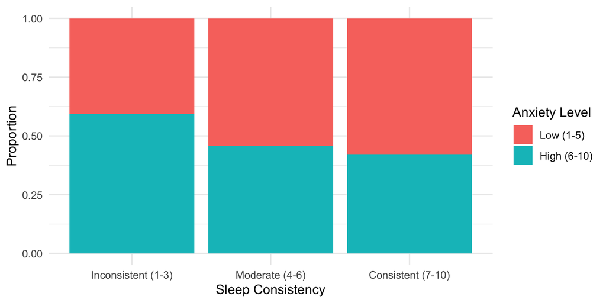

Figure 1: Stacked barplot showing the proportion of anxiety levels across three categories of sleep consistency.

```r
library(ggplot2)

ggplot(dat_final, aes(x = consist_3, fill = anxiety_2)) +
  geom_bar(position = "fill") +  # 或 position = "dodge"
  labs(
    x = "Sleep Consistency",
    y = "Proportion",
    fill = "Anxiety Level"
  ) +
  theme_minimal()
```

```r
set.seed(1)
tbl <- table(dat_final$anxiety_2, dat_final$consist_3)
knitr::kable(tbl)
```

Table 1: Contingency table of Sleep Consistency and Anxiety Level

|  | Inconsistent (1-3) | Moderate (4-6) | Consistent (7-10) |
| --- | --- | --- | --- |
| Low (1-5) | 31 | 70 | 80 |
| High (6-10) | 45 | 59 | 58 |

### 4.1.1 Chi-squared test of independence

**Hypothesis Testing Workflow**

```r
chisq <- chisq.test(tbl, correct = FALSE)
```

1. **Hypotheses**: $H_0$:Sleep consistency and anxiety levels are independent.vs $H_1$:Sleep consistency and anxiety levels are not independent.
2. **Assumptions**: Independence: Each participant’s response is assumed independent since the survey data were collected individually. Expected Cell Counts: All expected cell frequencies should be at least 5. As shown in Table 2, the expected counts are all greater than 5, so this condition is satisfied.
3. **Test statistic**: $T =\sum_i^k \ \sum_i^k \frac{(Y_i - e_i)^2}{e_i} \sim \chi^2_2$.
4. **Observed test statistic**: $t_0$ = 5.99
5. **p-value**: $P(\chi^2_2 \ge$ 5.99 ) = 0.05003
6. **Decision**: Since the p-value (0.05003) is greater than the significance level $\alpha = 0.05$, we fail to reject $H_0$. This suggests that there is no statistically significant association between anxiety level and sleep consistency in the sample.

**Expected Frequencies under Null Hypothesis**

```r
exp_tbl <- chisq$expected
knitr::kable(exp_tbl)
```

Table 2: Expected Counts for Sleep Consistency and Anxiety Level

|  | Inconsistent (1-3) | Moderate (4-6) | Consistent (7-10) |
| --- | --- | --- | --- |
| Low (1-5) | 40.10496 | 68.07289 | 72.82216 |
| High (6-10) | 35.89504 | 60.92711 | 65.17784 |

### 4.1.2 Limitations

The categorization of anxiety and sleep consistency may be too coarse. The data are self-reported, which could introduce bias. Also, a chi-squared test only checks association, not causation.And the borderline p-value (≈ 0.05) suggests that the result is unstable and should be interpreted with caution.

## 4.2 Is Sleep Duration Different between Low and High Anxiety Groups?

In Figure 2 , the left panel shows the distribution of sleep hours across anxiety groups, where the density curves suggest some differences between the groups. The right panel presents a scatterplot of sleep hours and anxiety scores with a fitted regression line, indicating a potential inverse trend between the two variables. To formally evaluate whether the mean sleep hours differ by anxiety group, we conduct a two-sample t-test.

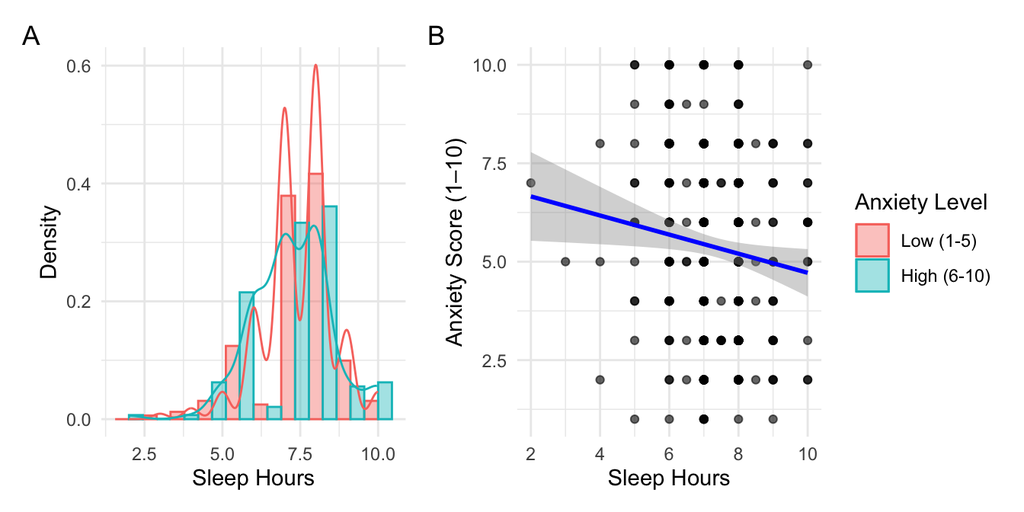

Figure 2: Visualisations of sleep duration and anxiety level. **A:** Histogram of sleep hours with density curves by anxiety group **B:** Scatterplot showing the relationship between sleep hours and anxiety score with regression line

```r
p1 <- ggplot(dat_final, aes(x = sleep_hours, fill = anxiety_2, color = anxiety_2)) +
  geom_histogram(aes(y = ..density..),
                 position = "dodge",
                 bins = 10, alpha = 0.4) +

  geom_density(alpha = 0.8, size = 0.5, fill = NA) +

  labs(
    x = "Sleep Hours",
    y = "Density",
    fill = "Anxiety Level",
    color = "Anxiety Level"
  ) +
  theme_minimal()

p2 <- ggplot(dat_final, aes(x = sleep_hours, y = anxiety_num)) +
  geom_point(alpha = 0.6) +
  geom_smooth(method = "lm", se = TRUE, color = "blue") +
  labs(
    x = "Sleep Hours",
    y = "Anxiety Score (1–10)"
  ) +
  theme_minimal()

final_plot <- p1 + p2 +
  plot_layout(guides = "collect") +
  plot_annotation(tag_levels = "A")

final_plot
```

```r
sleep_summary <- dat_final %>%
  group_by(anxiety_2) %>%
  summarise(
    n = n(),
    mean_sleep = mean(sleep_hours, na.rm = TRUE),
    sd_sleep = sd(sleep_hours, na.rm = TRUE)
  )

knitr::kable(sleep_summary)
```

Table 3: Summary statistics of sleep hours by anxiety group

| anxiety_2 | n | mean_sleep | sd_sleep |
| --- | --- | --- | --- |
| Low (1-5) | 181 | 7.419890 | 1.115767 |
| High (6-10) | 162 | 7.237654 | 1.272256 |

### 4.2.1 Two-Sample t-test

**Graphical Assumption Check**

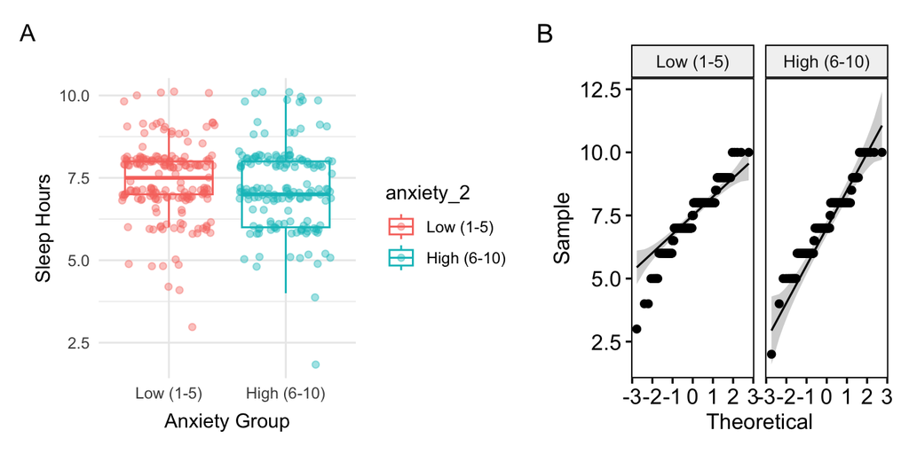

Figure 3: A boxplot showing the distribution of sleep hours across anxiety groups and a corresponding QQ plot to check normality. The boxplot indicates the spread and potential outliers, while the QQ plot assesses whether sleep hours in each group follow a normal distribution.

```r
mydata <- dat_final %>%
  select(anxiety_2, sleep_hours) %>%
  drop_na()

# A: Boxplot
p1 <- ggplot(mydata, aes(x = anxiety_2, y = sleep_hours, colour = anxiety_2)) +
  geom_boxplot(outlier.shape = NA) +
  geom_jitter(alpha = 0.4) +
  labs(x = "Anxiety Group", y = "Sleep Hours") +
  theme_minimal()

# B: QQ plot
library(ggpubr)
p2 <- ggqqplot(mydata, x = "sleep_hours", facet.by = "anxiety_2")

p1 + p2 + plot_annotation(tag_levels = 'A')
```

**Hypothesis Testing Workflow**

```r
set.seed(2)
# 1. Levene's Test
library(car)
levene <- leveneTest(sleep_hours ~ anxiety_2, data = dat_final)

# 2. Shapiro-Wilk test for each group
shapiro_l <- shapiro.test(dat_final$sleep_hours[dat_final$anxiety_2 == "Low (1-5)"])
shapiro_h <- shapiro.test(dat_final$sleep_hours[dat_final$anxiety_2 == "High (6-10)"])

TTest <- t.test(sleep_hours ~ anxiety_2, data = dat_final, var.equal = TRUE)
```

1. **Hypothesis**: Let $\mu_L$ and $\mu_H$ be the population mean sleep hours for the Low anxiety group (1–5) and the High anxiety group (6–10) respectively. $H_0$: $\mu_L$ = $\mu_H$ vs $H_1$: $\mu_L \ne \mu_H$
2. **Assumptions**:From the Table 3, the two groups have similar standard deviations, indicating comparable variability. Further, Levene’s test does not reject the null hypothesis of equal variances, supporting the homogeneity of variance assumption. For normality, Shapiro-Wilk tests were conducted on both groups. The results showed p-values less than 0.05, suggesting some departure from perfect normality. However, as Shapiro-Wilk is highly sensitive in large samples, the QQ plots(in the right panel of Figure 3) were also examined, which indicated that deviations were not severe. Given that both groups have relatively large sample sizes (n > 30), the Central Limit Theorem ensures that the sampling distribution of the mean can be approximated by a normal distribution. Thus, the normality assumption is reasonably satisfied. Finally, since the two groups were independently sampled, the independence assumption holds.

Therefore, the main assumptions for the two-sample t-test (independence, equal variances, and approximate normality) can be considered satisfied.

### 4.2.2 Limitations

The main limitations of this study include the following: First, the normality assumption was not fully satisfied, as the Shapiro-Wilk test indicated deviations, although the Central Limit Theorem partly alleviates this issue given the large sample size. Second, the analysis was based on cross-sectional data, which prevents causal conclusions about the relationship between sleep and anxiety. Third, potential confounding variables such as lifestyle or health conditions were not controlled, which may influence both sleep and anxiety levels.

## 4.3 Do individuals with different levels of anxiety report different average exercise hours per week?

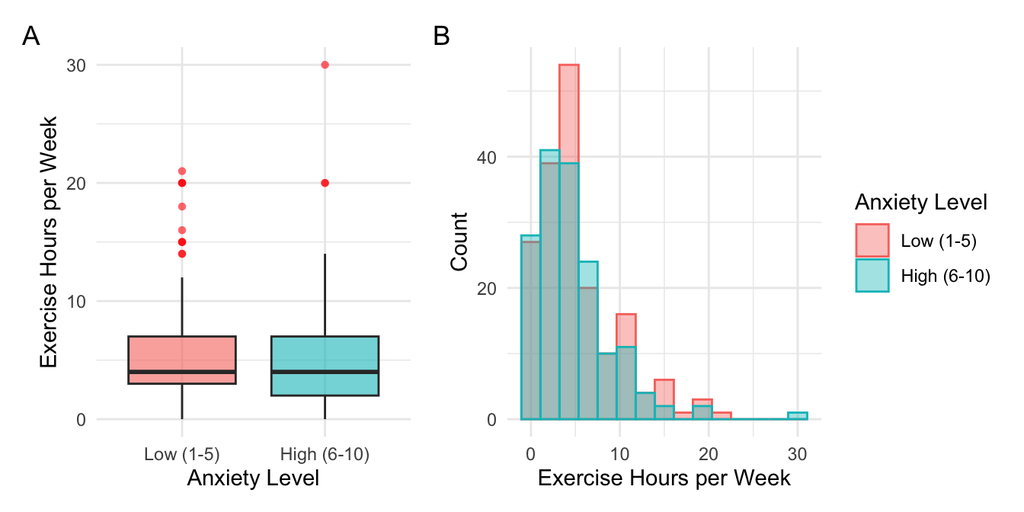

Figure 4: Visualisations of exercise hours by anxiety level. **A:** Boxplot of Exercise Hours by Anxiety Level **B:** Histogram of Exercise Hours by Anxiety Level.

```r
p1 <- ggplot(dat_final, aes(x = anxiety_2, y = exercise_num, fill = anxiety_2)) +
  geom_boxplot(alpha = 0.6, outlier.color = "red", outlier.shape = 16) +
  labs(
    x = "Anxiety Level",
    y = "Exercise Hours per Week"
  ) +
  theme_minimal() +
  theme(legend.position = "none")

p2 <- ggplot(dat_final, aes(x = exercise_num, fill = anxiety_2, color = anxiety_2)) +
  geom_histogram(position = "identity", bins = 15, alpha = 0.4) +
  labs(
    x = "Exercise Hours per Week",
    y = "Count",
    fill = "Anxiety Level",
    color = "Anxiety Level"
  ) +
  theme_minimal()

final_plot <- p1 + p2 +
  plot_layout(guides = "collect") +
  plot_annotation(tag_levels = "A")
final_plot
```

```r
set.seed(3)

d <- dat_final |>
  dplyr::select(anxiety_2, exercise_num) |>
  tidyr::drop_na()

tt_obs <- t.test(exercise_num ~ anxiety_2, data = d)
t0 <- as.numeric(tt_obs$statistic)

B <- 10000
t_perm <- replicate(B, {
  lab <- sample(d$anxiety_2)
  as.numeric(t.test(d$exercise_num ~ lab)$statistic)
})


p_perm_t <- mean(abs(t_perm) >= abs(t0))
```

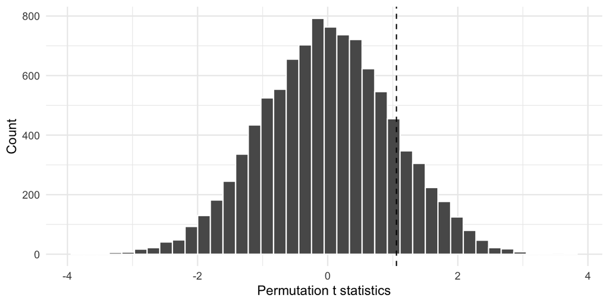

Figure 5: This figure shows what the differences between groups might look like if there were actually no real difference. The black bars represent the range of results we would expect just by random chance. The dashed line shows the result from our real data. Since the dashed line falls right within the main bulk of the black bars, our observed difference looks very similar to what could happen by chance. In other words, the test suggests there is no strong evidence of a real difference between the groups.

```r
library(ggplot2)
tibble(stat = t_perm) |>
  ggplot(aes(x = stat)) +
  geom_histogram(bins = 40, color = "white") +
  geom_vline(xintercept = t0, linetype = "dashed") +
  labs(x = "Permutation t statistics",
       y = "Count",
       ) +
  theme_minimal()
```

### 4.3.2 Limitation

A limitation of this permutation t-test is that it relies on the assumption of exchangeability under the null hypothesis, which may not hold if the sample is biased or dependent. In addition, because the p-value is obtained through simulation, results can vary slightly across runs depending on the random seed. Another limitation is that the test result is only valid for the given sample and may not generalise to the wider population.

# 5 Conclusion

This study investigated the relationship between anxiety levels and three lifestyle factors: sleep duration, sleep regularity, and weekly exercise hours. Across chi-squared, two-sample t-test, and permutation t-test analyses, no statistically significant differences were found between high and low anxiety groups.

These results may stem from methodological limitations: the relatively small sample size, reliance on self-reported data, and coarse grouping of variables may obscure subtle effects. In addition, uncontrolled factors (such as stress or health conditions) may also influence both sleep and anxiety. Therefore, the findings of this study are more likely to reflect limitations of the data and methodology rather than the absence of an association between these three variables and anxiety. Future research, conducted with larger samples, more dimensions, and more precise measurements, may reveal more nuanced effects.

## References

Association between sleep duration and anxiety in US adults: A nationally representative cross-sectional study. (2023). *Psychology Research and Behavior Management*. https://www.dovepress.com/association-between-sleep-duration-and-anxiety-in-us-adults-a-national-peer-reviewed-fulltext-article-PRBM

Firke, S. (2024). *Janitor: Simple tools for examining and cleaning dirty data*. https://github.com/sfirke/janitor

Li, D.-R., Li, Z.-X., Li, M.-H., et al. (2025). Regular sleep patterns, not just duration, critical for mental health: Association of accelerometer-derived sleep regularity with incident depression and anxiety. *Psychological Medicine*, *55*, e239. https://doi.org/10.1017/S0033291725101281

R Core Team. (2024). *R: A language and environment for statistical computing*. R Foundation for Statistical Computing. https://www.R-project.org/

Wainberg, M., Jones, S. E., Beaupre, L. M., et al. (2021). Association of accelerometer-derived sleep measures with lifetime psychiatric diagnoses: A cross-sectional study of 89,205 participants from the UK biobank. *PLOS Medicine*, *18*(10), e1003782. https://doi.org/10.1371/journal.pmed.1003782

Wickham, H. (2023a). *Stringr: Simple, consistent wrappers for common string operations*. https://stringr.tidyverse.org

Wickham, H. (2023b). *Tidyverse: Easily install and load the tidyverse*. https://tidyverse.tidyverse.org

Wickham, H., & Bryan, J. (2025). *Readxl: Read excel files*. https://readxl.tidyverse.org